# Lecture 7: Structuring ggplot2

Nick Huntington-Klein

22 April, 2020

## Structuring ggplot

- Last time we went through the basics of the grammar of graphics
- And how to put together a ggplot graph:
- Data, aesthetics, geometry

## Today!

- We’ll talk about different ways of changing the *structure* of your ggplot
- Scales and coordinates, labels and legends, new geometries
- There are infinite possibilities here, we can’t cover everything
- The goal is to reduce unknown unknowns so you know where to look/Google
- Also, just start typing in RStudio and see what autocompletes!

## Scales

- Every axis (aesthetic element) has a *scale*
- These scales are fully manipulable and label-able!
- `scale_axisname_type`

## Discrete and Continuous Scales

- For example:
- `scale_x_continuous` for a continuous x-axis
- `scale_x_discrete` for a discrete one
- Or similarly `scale_y_continuous`, `scale_color_continuous`, `scale_color_gradient`, `scale_fill_discrete`, and so on and so on

## Discrete and Continuous Scales

- Use to:
- Set colors, set limits (want the axis to extend beyond its values? `limits`)
- Name the scale
- Label values (for dicrete values, or perhaps as percents?)

## Setting Values Manually

- `scale_x_manual` for discrete plots will let you set things by hand
- For example if `x` is different companies and you want to pick each company’s brand color for its bar

## Examples

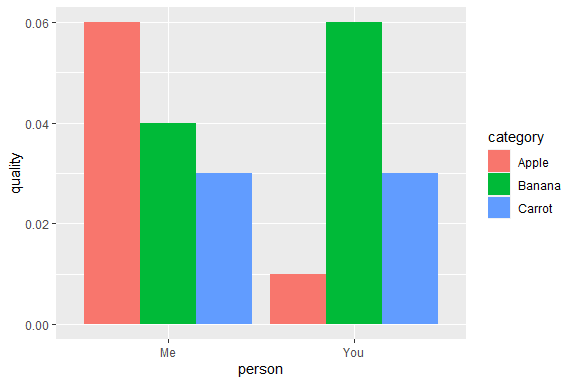

```r
data <- tibble(category = c('Apple','Banana','Carrot','Apple','Banana','Carrot'),
               person = c('Me','Me','Me','You','You','You'),
               quality = c(.06,.04,.03,.01,.06,.03))
ggplot(data, aes(x = person, y = quality, fill = category)) + geom_col(position = 'dodge')
```

## Setting Scales

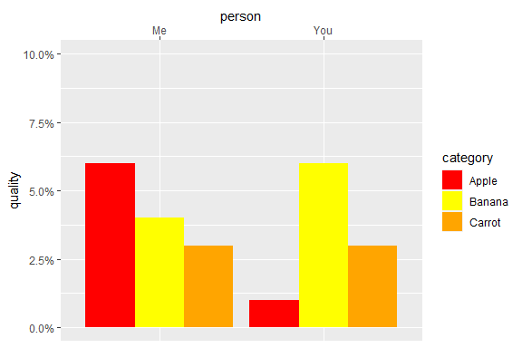

```r
ggplot(data, aes(x = person, y = quality, fill = category)) + geom_col(position = 'dodge') +
  scale_y_continuous(labels = scales::percent, limits = c(0,.1)) +
  scale_x_discrete(position = 'top') +
  scale_fill_manual(values = c('Apple'='red','Banana'='yellow','Carrot'='orange'))
```

## Setting Color or Fill Scales

- Selecting a color scale is important - we’ve discussed discrete and continuous palettes
- The **paletteer** package ([see documentation](https://emilhvitfeldt.github.io/paletteer/)) compiles a whole buncha palettes and is easy to use - use `palettes_d_names` or `palettes_c_names` to list discrete and continuous palettes in the package
- Or `palettes_dynamic_names` to see continuous binned palettes where the colors used depend on how many shades you need
- **RColorBrewer** is also a classic

## Setting Color or Fill Scales

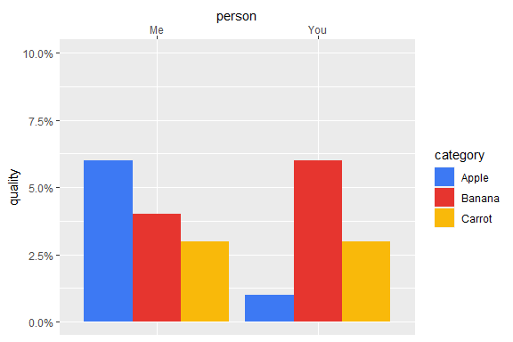

```r
library(paletteer)
ggplot(data, aes(x = person, y = quality, fill = category)) + geom_col(position = 'dodge') +
  scale_y_continuous(labels = scales::percent, limits = c(0,.1)) +
  scale_x_discrete(position = 'top') +
  scale_fill_paletteer_d('yarrr::google')
```

## Setting Color or Fill Scales

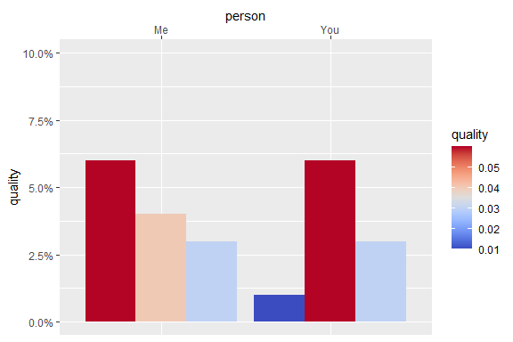

```r
ggplot(data, aes(x = person, y = quality, group = category, fill = quality)) + geom_col(position = 'dodge') +
  scale_y_continuous(labels = scales::percent, limits = c(0,.1)) +
  scale_x_discrete(position = 'top') +
  scale_fill_paletteer_c('pals::coolwarm')
```

## Transformations

- We can transform values as we plot them
- Many `scale_something_continuous` entries have a `trans` option, set to `date`, `log`, `probability`, `reciprocal`, `sqrt`, `reverse`, etc. etc. to perform that transformation before plotting
- Typically that’s something from the `scales` package. Other options like `scales::percent`
- You can also do things like `scale_x_log10` or `scale_y_reverse` for some common transforms
- `scale_something_binned()` takes a continuous value and puts it in bins, handy sometimes for simplification

## Transformations

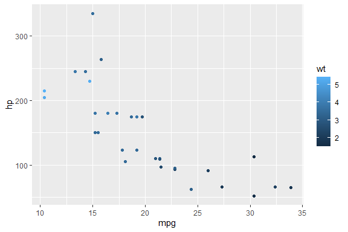

```r
ggplot(mtcars, aes(x = mpg, y = hp, color = wt)) +
  geom_point()
```

## Transformations

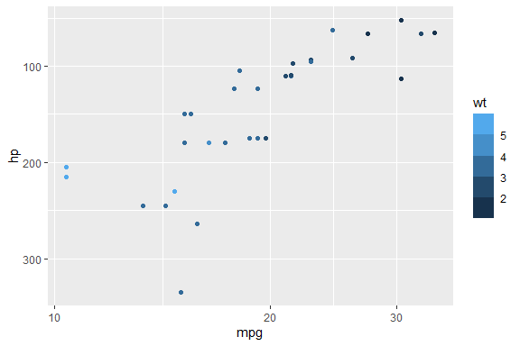

```r
ggplot(mtcars, aes(x = mpg, y = hp, color = wt)) +
  geom_point() +
  scale_x_log10() +
  scale_y_continuous(trans='reverse') +
  scale_color_binned()
```

## Log Scales

When to use log scales?

- When data is highly skewed, so a few huge observations are drawing all focus
- When the relationship is multiplicative so you want to show, say, percentage growth

## Documentation

- There are a zillion options
- Be sure to use `help(whatever)` before using something
- Not sure what the function is? Check the **ggplot2** documentation page
- Or just start typing `scales_` or whatever and see what pops up in autocomplete in RStudio

## Labels with labs()

- Please label your axes and graphs!!
- Label legends too by naming their axes
- Captions and subcaptions available too
- Annotation and labeling data points we’ll do next time

## All Kinds of Labels

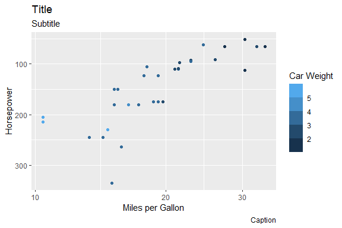

```r
data(mtcars)
mtcars <- mtcars %>% mutate(CarName = row.names(mtcars))
ggplot(mtcars, aes(x = mpg, y = hp, color = wt)) + geom_point() +
  scale_x_log10() + scale_y_reverse() + scale_color_binned() +
  labs(x = 'Miles per Gallon', y = 'Horsepower', color = 'Car Weight',
       title = 'Title', subtitle = 'Subtitle', caption = 'Caption')
```

## Moving the Legend

- Working with **ggplot2** legends is one of the trickier things
- we’ll do a lot more with aesthetic details next time but for now let’s just move it and outline it.

## Moving the Legend

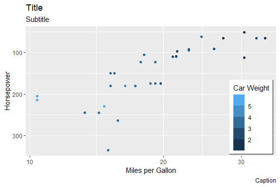

```r
ggplot(mtcars, aes(x = mpg, y = hp, color = wt)) + geom_point() +
  scale_x_log10() + scale_y_reverse() + scale_color_binned() +
  labs(x = 'Miles per Gallon', y = 'Horsepower', color = 'Car Weight',
       title = 'Title', subtitle = 'Subtitle', caption = 'Caption') +
  theme(legend.position = c(.9,.3), legend.box.background = element_rect(color='black'))
```

## Or Removing It

I Google this every time

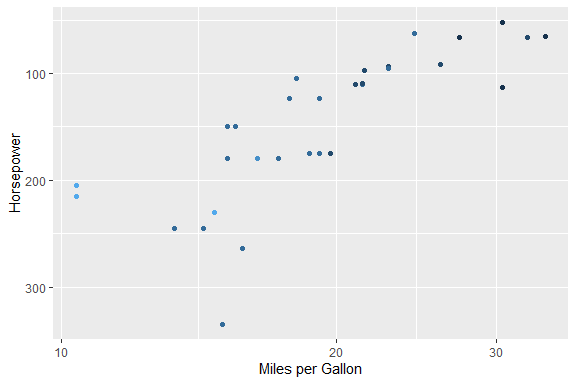

```r
ggplot(mtcars, aes(x = mpg, y = hp, color = wt)) + geom_point() +
  scale_x_log10() + scale_y_reverse() + scale_color_binned() +
  labs(x = 'Miles per Gallon', y = 'Horsepower', color = 'Car Weight') +
  guides(color = FALSE)
```

## Overlaid Graphs

- In addition to adding chart elements, we can add whole new geometries over the top
- Some stack naturally (adding a `geom_smooth` best fit line over top, for example)
- For others we may have to change the data or aesthetic as we go

## Overlaid Graphs

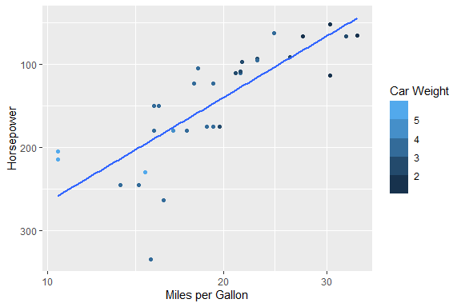

```r
ggplot(mtcars, aes(x = mpg, y = hp, color = wt)) + geom_point() +
  scale_x_log10() + scale_y_reverse() + scale_color_binned() +
  labs(x = 'Miles per Gallon', y = 'Horsepower', color = 'Car Weight') +
  geom_smooth(method='lm', se = FALSE)
```

## Overlaid Graphs

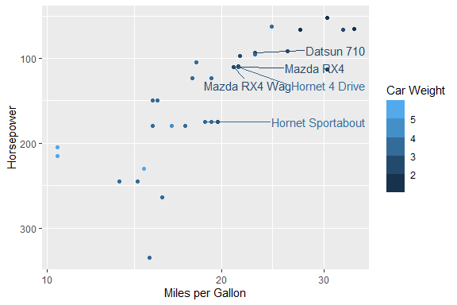

```r
ggplot(mtcars, aes(x = mpg, y = hp, color = wt)) + geom_point() +
  scale_x_log10() + scale_y_reverse() + scale_color_binned() +
  labs(x = 'Miles per Gallon', y = 'Horsepower', color = 'Car Weight') +
  geom_text_repel(data = mtcars %>% slice(1:5),aes(label = CarName),hjust=-1)
```

## Facets

- Separate graphs by group!

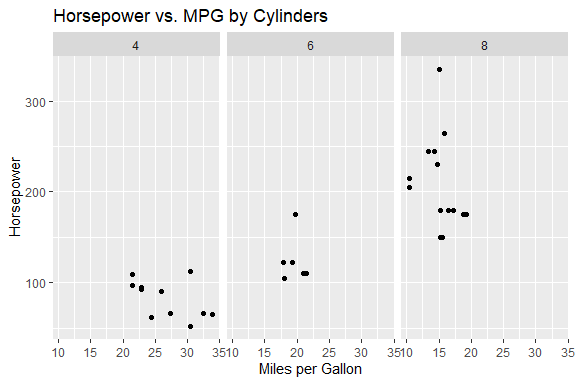

```r
ggplot(mtcars, aes(x = mpg, y = hp)) + geom_point() +
  facet_wrap('cyl') +
  labs(x = 'Miles per Gallon', y = 'Horsepower', title = 'Horsepower vs. MPG by Cylinders')
```

## Downloadable Geometries

- There are so, so many **ggplot2** geometries available
- Way too many to cover - see the [ggplot2 extension gallery](https://exts.ggplot2.tidyverse.org/gallery/) in addition to the base-**ggplot2** cheat sheet from last time
- I will go over some popular ones. Google package names for more detailed explanations
- We won’t go deeply into how to use these, this is more to show you they exist and an example so you can look further yourself if you’re interested

## geom_text to geom_repel

- We covered geom_text last time
- But the text gets in the way! How did I handle this in that `mtcars` graph I just did?

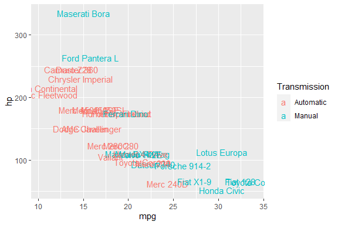

## geom_text_repel

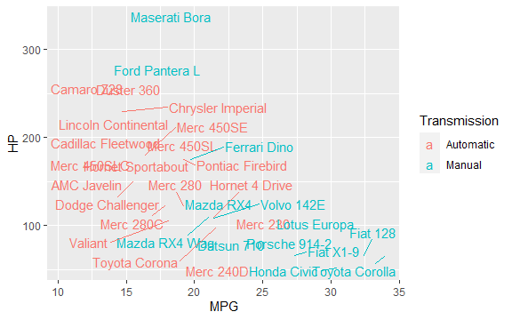

```r
library(ggrepel); data(mtcars)
mtcars <- mtcars %>%
  mutate(Transmission = factor(am, labels = c('Automatic','Manual')),
         CarName = row.names(mtcars))
ggplot(mtcars, aes(x = mpg, y = hp, color = Transmission, label = CarName)) +
  geom_text_repel() + labs(x = 'MPG',y='HP')
```

## geom_label_repel adds boxes

- That was still pretty busy. Text graphs really only work with a smaller number of labels (or short ones)

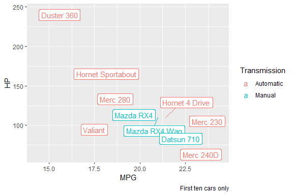

```r
ggplot(mtcars[1:10,], aes(x = mpg, y = hp, color = Transmission, label = CarName)) +
  geom_label_repel() + labs(x = 'MPG',y='HP', caption = 'First ten cars only')
```

## ggridges

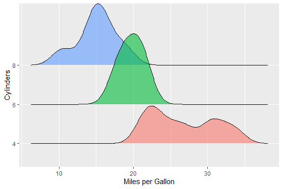

```r
#A common need is to graph distributions across groups
library(ggridges)
ggplot(mtcars, aes(x = mpg, y = factor(cyl), fill = factor(cyl))) +
  geom_density_ridges(alpha = .6) +
  labs(x = 'Miles per Gallon', y = 'Cylinders') +
  guides(fill = FALSE)
```

## ggmap

- **ggplot2** has *extensive* mapping capabilities
- For this class I’ll recommend the much-simpler Excel or Tableau for maps
- But for the heavy stuff there’s a whole world here, linked to Google Maps (including having an actual map underneath your data-map)
- Including straightforward-ish map *animations* with the **tmap** package
- Also see libraries **choloropleth**, **tigris**, **tmap**, **sf**, **fiftystater**

## ggalluvial

- Those neato-looking Sankey graphs are all the rage. Make sure it is actually helpful!

```r
library(ggalluvial)
mtcars <- mtcars %>%
  group_by(cyl,vs,gear) %>%
  mutate(Frequency = n())
ggplot(mtcars, aes(y=Frequency,axis1=factor(cyl),
                   axis2=factor(vs),axis3=factor(gear),fill=factor(am))) +
         geom_alluvium() +
  scale_x_discrete(limits = c("Cylinder","Engine Type","Number of Gears")) +
  geom_stratum() + geom_text(stat = "stratum", infer.label = TRUE)
```

## ggalluvial

Gives us…

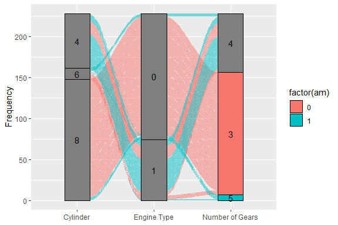

## ggalluvial

- Or for changes over something more continuous…
- Like a stacked bar chart changing over time, slightly better (this example is ugly)

```r
data(gss_cat, package='forcats')
gss_cat <- gss_cat %>%
  group_by(year,marital) %>%
  summarize(Proportion = n()/nrow(gss_cat))
ggplot(gss_cat, aes(x = year, y = Proportion,
                    alluvium = marital, fill = marital, color = marital)) +
  geom_alluvium()
```

## ggalluvial

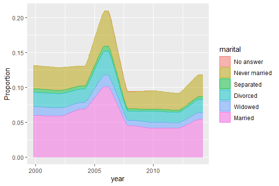

## ggforce

- **ggforce** is a package with LOTS of extras, especially for facets
- An especially handy one is `facet_zoom` for showing all data but focusing in on some
- Focus focus focus your audience!
- Can also be used to focus on a range with `xlim` or `ylim`

## ggforce’s facet_zoom

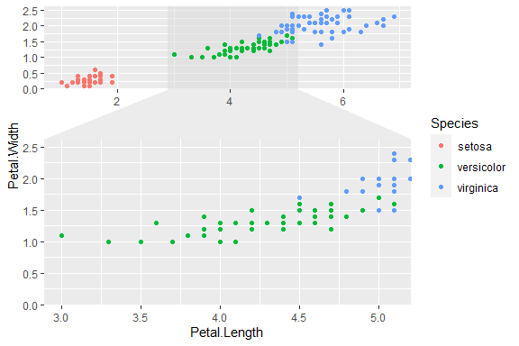

```r
library(ggforce)
ggplot(iris, aes(Petal.Length, Petal.Width, colour = Species)) +
  geom_point() +
  facet_zoom(x = Species == 'versicolor')
```

## ggalt

- **ggalt** is another package with lots of additional geoms
- Including some functions to automatically encircle your data (setting things apart!)
- Two nice ones are `geom_lollipop` for lollipop charts (a nice-looking alternative to a bar chart)
- and `geom_dumbbell` for dumbbell charts (nice for “to-and-from” changes within groups)

## `geom_lollipop`

```r
library(ggalt); data(gss_cat, package='forcats')
gss_cat <- gss_cat %>%
  group_by(marital) %>%
  summarize(PropAbove = mean(rincome == '$25000 or more'))
ggplot(gss_cat, aes(y=PropAbove, x = reorder(marital,PropAbove))) +
  geom_lollipop() + labs(x = 'Marital Status', y ='Proportion Earning $25k+')
```

## `geom_lollipop`

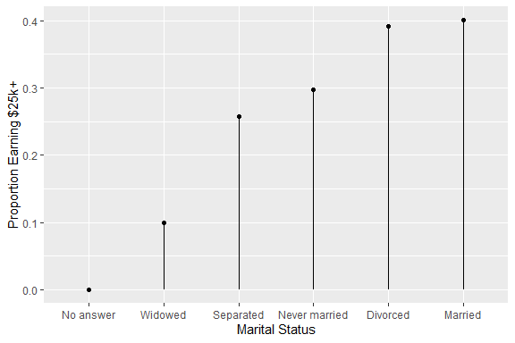

## geom_dumbbell

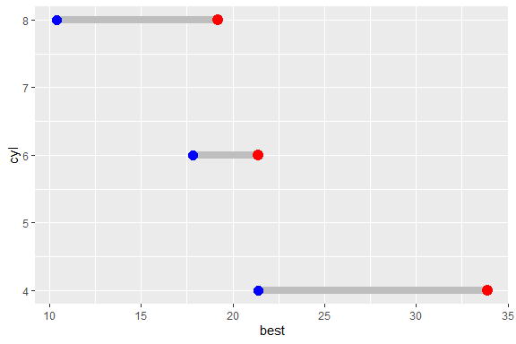

```r
top_bottom <- mtcars %>% group_by(cyl) %>%
  summarize(worst = max(mpg), best = min(mpg))
ggplot(top_bottom, aes(y = cyl, x = best, xend = worst)) +
  geom_dumbbell(size = 3, color = 'gray',colour_x = 'blue', colour_xend = 'red')
```

## gganimate

- The **gganimate** package makes it fairly straightforward to animate your graphs
- Take a graph and use a `transition_` command to have it assign one axis to *time*
- Make sure this actually adds something! This limits where the graph can be shown

## gganimate

```r
library(gganimate)
data(gapminder)
options(gganimate.dev_args = list(width = 650, height = 400))
p <- ggplot(gapminder,
       aes(x = gdpPercap, y = lifeExp, color = continent)) +
  geom_point() +
  scale_x_log10() +
  labs(x = "GDP per Capita (log scale)", y = "Life Expectancy",
       title = "GDP and Life Expectancy by Country, 1952-2007",
       color = 'Continent') +
  transition_time(year))
animate(p,nframes = 200,end_pause = 30)
```

## gganimate

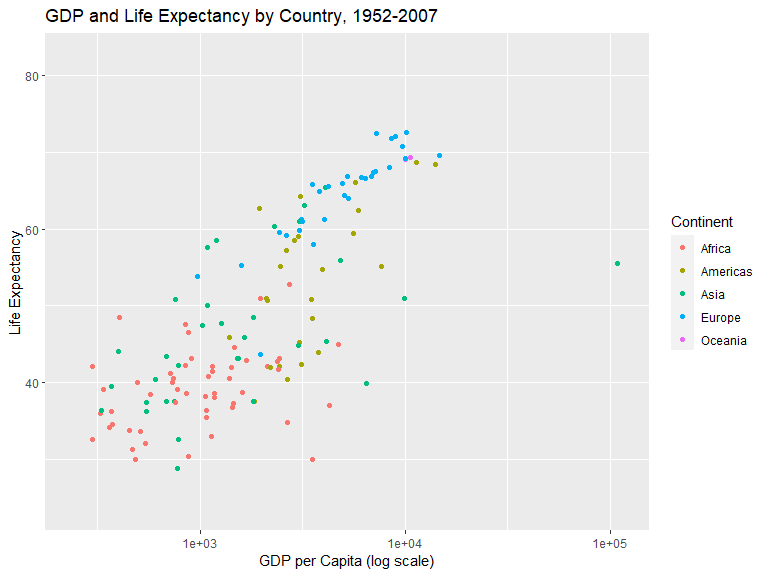

## Imitation and Flattery

- Pick one of these graphs or from the previous lecture
- Go into the geometry’s help file and recreate an example, or the graph in these slides
- Mess with the scales and labels! Try to get it to work!